# STATS 32 Session 4: Data Transformation

Kenneth Tay

Oct 11, 2018

# Recap of session 3: data visualization

- Different types of plots for visualizing different types of variables
- Grammar of graphics for `ggplot2`
  - Essential elements: **data**, **geom**etries, **aes**thetics
  - **Layers** allow us to build more complex plots

# `ggplot2` syntax

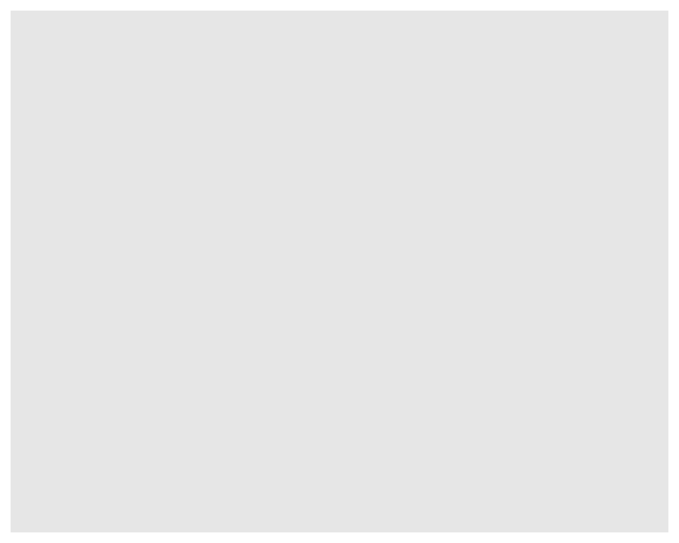

```r
library(ggplot2)
ggplot()
```

# `ggplot2` syntax

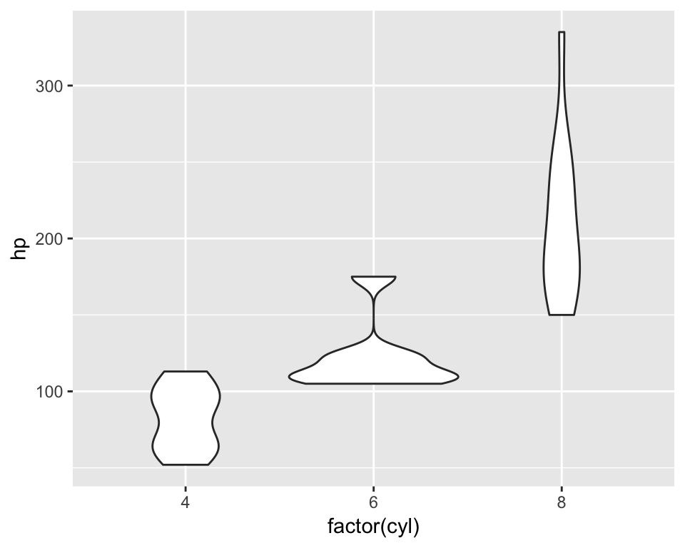

```r
ggplot() +
    geom_violin(data = mtcars,
                mapping = aes(x = factor(cyl), y = hp))
```

# `ggplot2` syntax

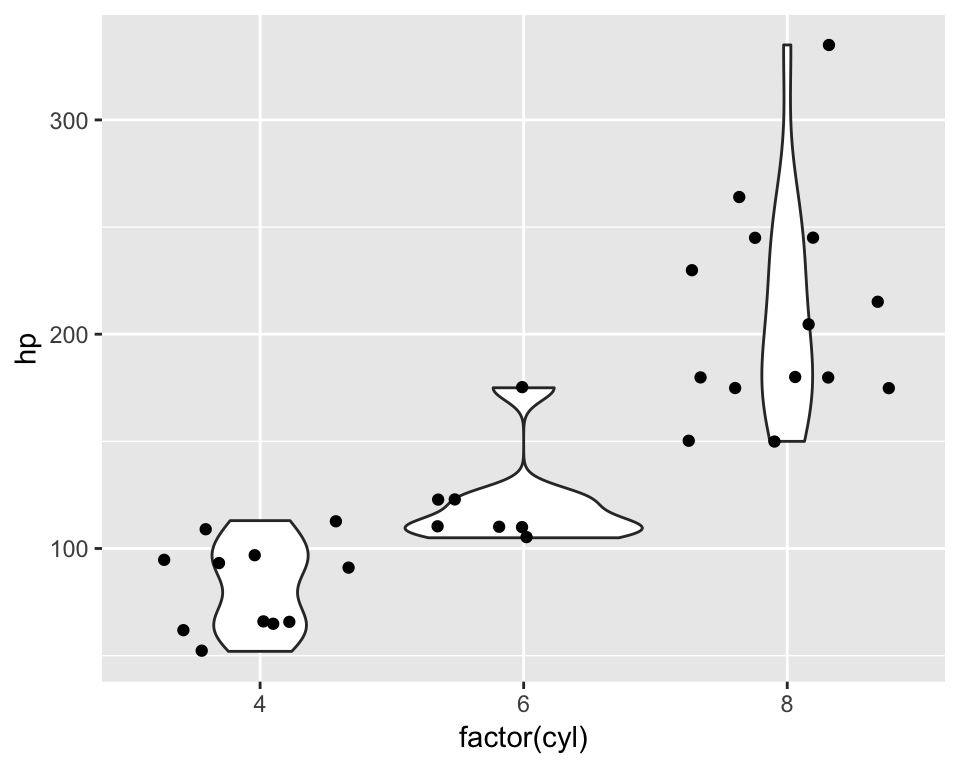

```r
ggplot() +
    geom_violin(data = mtcars,
                mapping = aes(x = factor(cyl), y = hp)) +
    geom_point(data = mtcars,
               mapping = aes(x = factor(cyl), y = hp),
               position = "jitter")
```

# `ggplot2` syntax

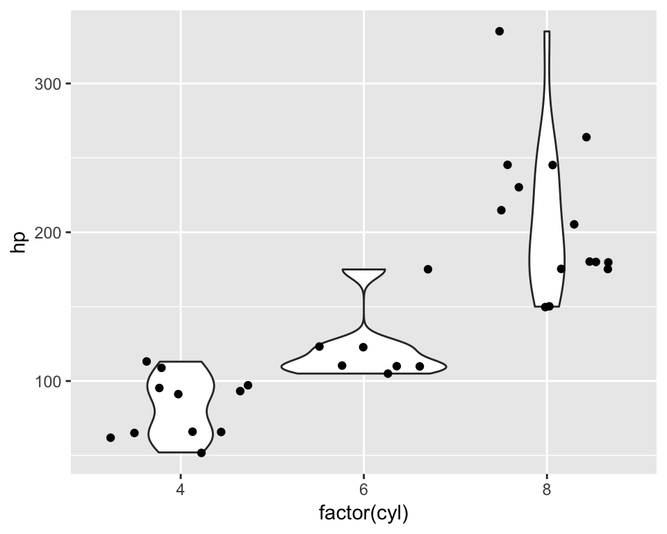

```r
ggplot(data = mtcars,
       mapping = aes(x = factor(cyl), y = hp)) +
    geom_violin() +
    geom_point(position = "jitter")
```

# `ggplot2` syntax

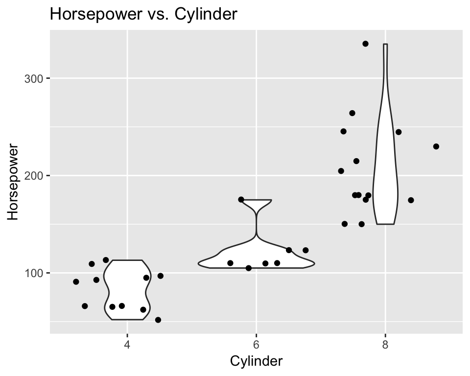

```r
ggplot(data = mtcars,
       mapping = aes(x = factor(cyl), y = hp)) +
    geom_violin() +
    geom_point(position = "jitter") +
    labs(title = "Horsepower vs. Cylinder", x = "Cylinder",
         y = "Horsepower")
```

# `ggplot2` syntax

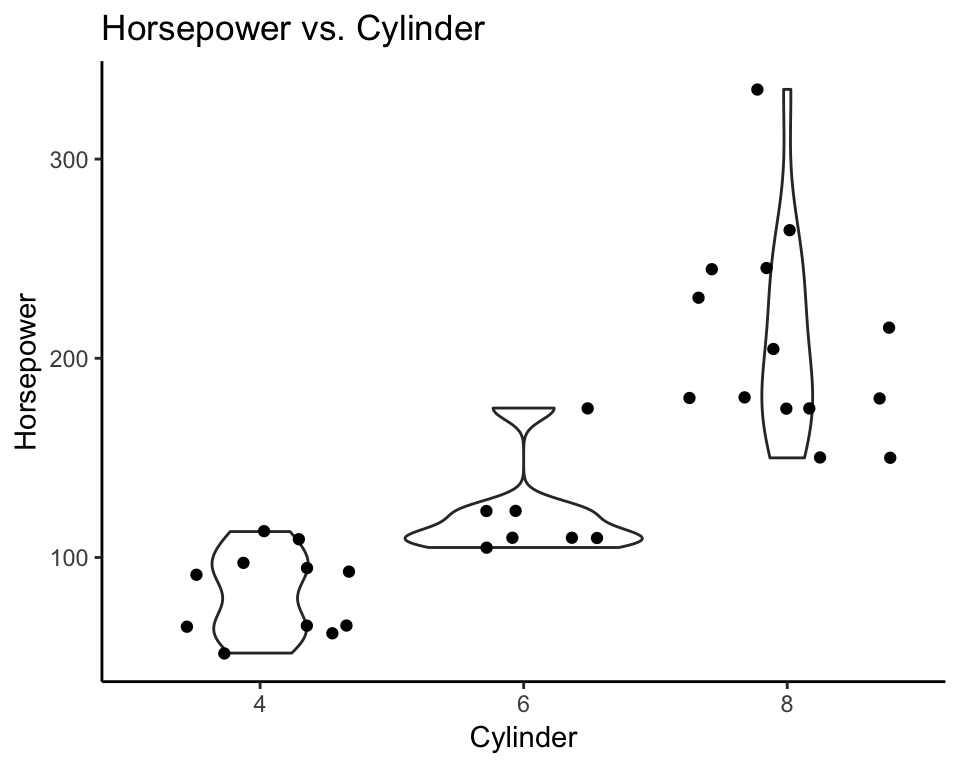

```r
ggplot(data = mtcars,
       mapping = aes(x = factor(cyl), y = hp)) +
    geom_violin() +
    geom_point(position = "jitter") +
    labs(title = "Horsepower vs. Cylinder", x = "Cylinder",
         y = "Horsepower") +
    theme_classic()
```

# Agenda for today

- Transforming data with `dplyr` (and `%>%` syntax)

# Why do we need to transform data?

We rarely get data in exactly the form we need!

- Need to create new variables or summaries
- Need to rename or reorder variables

Transforming data in R is made easy by the `dplyr` package (“official” cheat sheet available [here](https://www.rstudio.com/resources/cheatsheets/)).

# The 5 basic `dplyr` verbs

- `select()`: pick variables by their names
- `mutate()`: create new variables based on existing ones
- `arrange()`: reorder rows
- `filter()`: pick observations by their values
- `summarize()`: collapse many values down to a single summary

# Toy example: Student scores

```r
scores
```

```
##     Name English Math Science History Spanish
## 1 Andrew      60   96      80      56      77
## 2   John      66   55      56      64      77
## 3   Mary      92   63      70      62      98
## 4   Jane      80   76      89      55      40
## 5    Bob      80   80      82      48      50
## 6    Dan      58   52      79      90      61
```

# `select`: pick subset of variables/columns by name

History teacher: “I just want their names and History scores”

1. Take the `scores` dataset.
2. **Select** the Name and History columns.

# `mutate`: create new columns based on old ones

Form teacher: “What are their total scores?”

1. Take the `scores` dataset.
2. Add a new column by **mutating** existing columns: for each row, Total = English + Math + Science + History + Spanish

# `arrange`: reorder rows

Form teacher: “Can I have the students in order of overall performance?”

1. Take the `scores` dataset.
2. **Arrange** rows by the Total column.

# `arrange`: reorder rows

Form teacher: “No no, better students on top please…”

1. Take the `scores` dataset.
2. **Arrange** rows by the Total column, but in descending order.

# `arrange`: reorder rows

Form teacher: “Can I have them in descending order of total scores, but if students tie, then by alphabetical order?”

1. Take the `scores` dataset.
2. **Arrange** rows first by the Total column in descending order, then by the Name column (in ascending order).

# `filter`: pick observations by their values

History teacher: “I want to see which students scored less than 60 for history”

1. Take the `scores` dataset.
2. **Filter** for rows where the value in the History column is less than 60.

# `summarize`: get summaries of data

Academic: “I want to know the correlation between math and science scores”

1. Take the `scores` dataset.
2. **Summarize** the dataset by taking the correlation of the Math and Science columns.

Science teacher: “I want to know the mean and standard deviation of the scores for science”

1. Take the `scores` dataset.
2. **Summarize** the dataset by taking the mean of the Science column and the standard deviation of the science column.

# `group_by`: use `dplyr` verbs on a group-by-group basis

Academic: “I want to know if the boys scored better than the girls in Spanish”

1. Take the `scores` dataset.
2. **Group** the dataset rows by gender (assuming there is a gender column).
3. **Summarize** each group of the dataset by taking the mean of the Spanish column.

# Practice

Language teacher: “I want to know which students scored < 70 for both English and Spanish, but I just want names”

# Practice

Language teacher: “I want to know which students scored < 70 for both English and Spanish, but I just want names”

1. Take the `scores` dataset.
2. **Filter** for the rows which have English < 70 and Spanish < 70.
3. **Select** the Name column.

# Practice

Math teacher: “I want to know which students scored < 70 for math, and I just want their names and their mean score across subjects”

# Practice

Math teacher: “I want to know which students scored < 70 for math, and I just want their names and their mean score across subjects”

1. Take the `scores` dataset.
2. **Filter** for the rows which have Math < 70.
3. **Mutate** existing columns to get a new one: Mean = (English + … + Spanish)/5.
4. **Select** the Name and Mean columns.

# `select`: pick subset of variables/columns by name

History teacher: “I just want their names and History scores”

1. Take the `scores` dataset.
2. **Select** the Name and History columns.

```r
scores %>%
    select(Name, History)
```

```
##     Name History
## 1 Andrew      56
## 2   John      64
## 3   Mary      62
## 4   Jane      55
## 5    Bob      48
## 6    Dan      90
```

# `mutate`: create new columns based on old ones

Form teacher: “What are their total scores?”

1. Take the `scores` dataset.
2. Add a new column by **mutating** existing columns: for each row, Total = English + Math + Science + History + Spanish

```r
scores <- scores %>%
    mutate(Total = English + Math + Science + History + Spanish)
scores
```

```
##     Name English Math Science History Spanish Total
## 1 Andrew      60   96      80      56      77   369
## 2   John      66   55      56      64      77   318
## 3   Mary      92   63      70      62      98   385
## 4   Jane      80   76      89      55      40   340
## 5    Bob      80   80      82      48      50   340
## 6    Dan      58   52      79      90      61   340
```

# `arrange`: reorder rows

Form teacher: “Can I have the students in order of overall performance?”

1. Take the `scores` dataset.
2. **Arrange** rows by the Total column.

```r
scores %>%
    arrange(Total)
```

```
##     Name English Math Science History Spanish Total
## 1   John      66   55      56      64      77   318
## 2   Jane      80   76      89      55      40   340
## 3    Bob      80   80      82      48      50   340
## 4    Dan      58   52      79      90      61   340
## 5 Andrew      60   96      80      56      77   369
## 6   Mary      92   63      70      62      98   385
```

# `arrange`: reorder rows

Form teacher: “No no, better students on top please…”

1. Take the `scores` dataset.
2. **Arrange** rows by the Total column, but in descending order.

```r
scores %>%
    arrange(desc(Total))
```

```
##     Name English Math Science History Spanish Total
## 1   Mary      92   63      70      62      98   385
## 2 Andrew      60   96      80      56      77   369
## 3   Jane      80   76      89      55      40   340
## 4    Bob      80   80      82      48      50   340
## 5    Dan      58   52      79      90      61   340
## 6   John      66   55      56      64      77   318
```

# `arrange`: reorder rows

Form teacher: “Can I have them in descending order of total scores, but if students tie, then by alphabetical order?”

1. Take the `scores` dataset.
2. **Arrange** rows first by the Total column in descending order, then by the Name column (in ascending order).

```r
scores %>%
    arrange(desc(Total), Name)
```

```
##     Name English Math Science History Spanish Total
## 1   Mary      92   63      70      62      98   385
## 2 Andrew      60   96      80      56      77   369
## 3    Bob      80   80      82      48      50   340
## 4    Dan      58   52      79      90      61   340
## 5   Jane      80   76      89      55      40   340
## 6   John      66   55      56      64      77   318
```

# `filter`: pick observations by their values

History teacher: “I want to see which students scored less than 60 for history”

1. Take the `scores` dataset.
2. **Filter** for rows where the value in the History column is less than 60.

```r
scores %>%
    filter(History < 60)
```

```
##     Name English Math Science History Spanish Total
## 1 Andrew      60   96      80      56      77   369
## 2   Jane      80   76      89      55      40   340
## 3    Bob      80   80      82      48      50   340
```

# More on filters

Other ways to make comparisons:

- `>`: greater than
- `<`: less than
- `>=`: greater than or equal to
- `<=`: less than or equal to
- `!=`: not equal to
- `==`: equal to (**Do not use `=` to test for equality!!**)

Combining comparisons:

- `!`: not
- `&`: and
- `|`: or

# More `filter` examples

Dan’s parents: “I just want Dan’s scores”

```r
scores %>%
    filter(Name == "Dan")
```

```
##   Name English Math Science History Spanish Total
## 1  Dan      58   52      79      90      61   340
```

Language teacher: “I want to know which students score < 50 for either English or Spanish”

```r
scores %>%
    filter(English < 50 | Spanish < 50)
```

```
##   Name English Math Science History Spanish Total
## 1 Jane      80   76      89      55      40   340
```

# `summarize`: get summaries of data

Academic: “I want to know the correlation between math and science scores”

1. Take the `scores` dataset.
2. **Summarize** the dataset by taking the correlation of the Math and Science columns.

```r
scores %>%
    summarize(corr = cor(Math, Science))
```

```
##        corr
## 1 0.5470561
```

# `summarize`: get summaries of data

Science teacher: “I want to know the mean and standard deviation of the scores for science”

1. Take the `scores` dataset.
2. **Summarize** the dataset by taking the mean of the Science column and the standard deviation of the science column.

```r
scores %>%
    summarize(Science_mean = mean(Science),
              Science_sd = sd(Science))
```

```
##   Science_mean Science_sd
## 1           76   11.54123
```

# `group_by`: use `dplyr` verbs on a group-by-group basis

Academic: “I want to know if the boys scored better than the girls in Spanish”

1. Take the `scores` dataset.
2. **Group** the dataset rows by gender (assuming there is a gender column).
3. **Summarize** each group of the dataset by taking the mean of the Spanish column.

```r
scores %>%
    group_by(Gender) %>%
    summarize(Spanish_mean = mean(Spanish))
```

```
## # A tibble: 2 x 2
##   Gender Spanish_mean
##   <chr>         <dbl>
## 1 F              69
## 2 M              66.2
```

# Chaining multiple `dplyr` commands

Language teacher: “I want to know which students scored < 70 for both English and Spanish, but I just want names”

1. Take the `scores` dataset.
2. **Filter** for the rows which have English < 70 and Spanish < 70.
3. **Select** the Name column.

```r
scores %>%
    filter(English < 70 & Spanish < 70) %>%
    select(Name)
```

```
##   Name
## 1  Dan
```

# Chaining multiple `dplyr` commands

Math teacher: “I want to know which students scored < 70 for math, and I just want their names and their mean score across subjects”

1. Take the `scores` dataset.
2. **Filter** for the rows which have Math < 70.
3. **Mutate** existing columns to get a new one: Mean = (English + … + Spanish)/5.
4. **Select** the Name and Mean columns.

```r
scores %>%
    filter(Math < 70) %>%
    mutate(Mean = (English + Math + Science + History + Spanish)/5) %>%
    select(Name, Mean)
```

```
##   Name Mean
## 1 John 63.6
## 2 Mary 77.0
## 3  Dan 68.0
```

# Today’s dataset: Flights from New York City

**Exploring flights from NYC to the Bay Area**

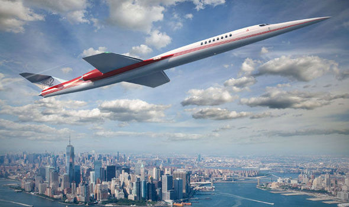

(Source: [Sunday Express](https://www.express.co.uk/news/science/621722/supersonic-private-plane-fly-Britons-New-York-three-hours-Concorde))

**Optional material**

# `transmute`: create new columns based on old ones, discard old ones

Form teacher: “I just want the mean score for each student”

```r
scores %>%
    transmute(mean = (English + Math + Science + History + Spanish) / 5)
```

# TRUE/FALSE statements

How does R understand the code `filter(History < 60)`?

- R checks each row of the dataset: is `History` less than 60 or not?
  - `History < 60` is a statement that is either `TRUE` or `FALSE`
  - If `TRUE`, keep the row
  - If not, discard it
- `filter(<condition>)` only returns the rows for which `<condition>` is `TRUE`
- Technical term for a statement that is either `TRUE` or `FALSE`: **boolean expression**

# TRUE/FALSE examples

```r
3 > 2
```

```
## [1] TRUE
```

```r
3 < 2
```

```
## [1] FALSE
```

```r
3 == 2
```

```
## [1] FALSE
```

```r
c(1, 2, 3, 1) == c(3, 2, 1, 2)
```

```
## [1] FALSE  TRUE FALSE FALSE
```

```r
c(1, 2, 3, 1) == 1
```

```
## [1]  TRUE FALSE FALSE  TRUE
```

# Be careful with `NA`s!

```r
1 == NA
```

```
## [1] NA
```

```r
NA == NA
```

```
## [1] NA
```

```r
is.na(NA)
```

```
## [1] TRUE
```